# Data Visualization - Mini-Project 1

Tom Mann `tmann4511@floridapoly.edu`

# Read in the data

```r
library(tidyverse)
```

```r
WC_data <- read_csv("https://raw.githubusercontent.com/reisanar/datasets/master/WorldCupMatches.csv")
```

> > For my analysis I will utilize the World Cup dataset. I am a big soccer fan and particularly interested in the World Cup 2014. This is due to the fact that Germany won this WC. I wanna explore the data to find out how we can win the next World cup :)

# First data visualization: Focus on Goals

> > In this section, the goal is to find out if home or away teams scored more goals. It is important to acknowledge that there is no real home advantage, as all games were played in Brazil.

```r
WC_data_goals <- WC_data %>%
  filter(Year == 2014) %>%
  summarize(
    Home_Team_Goals = sum(`Home Team Goals`),
    Away_Team_Goals = sum(`Away Team Goals`)
  )
```

> > Practice the function pivot_longer to reshape the data frame into long format

```r
WC_data_goals_long <- WC_data_goals %>%
  pivot_longer(cols = everything(), names_to = "category", values_to = "value")
```

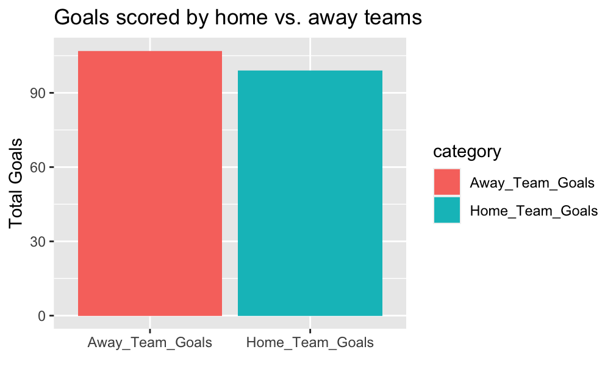

```r
ggplot(WC_data_goals_long, aes(x = category, y = value, fill = category)) +
  geom_bar(stat = "identity") +
  labs(x = "", y = "Total Goals") +  # Customize axis labels
  ggtitle("Goals scored by home vs. away teams")
```

# Second data vizualisation : Focusing on attendance and stadiums

```r
stadium_attendance <- WC_data %>%
  filter(Year == 2014) %>%
  group_by(Stadium) %>%
  summarize(
    avg_attendance = mean(Attendance)
  ) %>%
  arrange(desc(avg_attendance)) %>%
  na.omit()
```

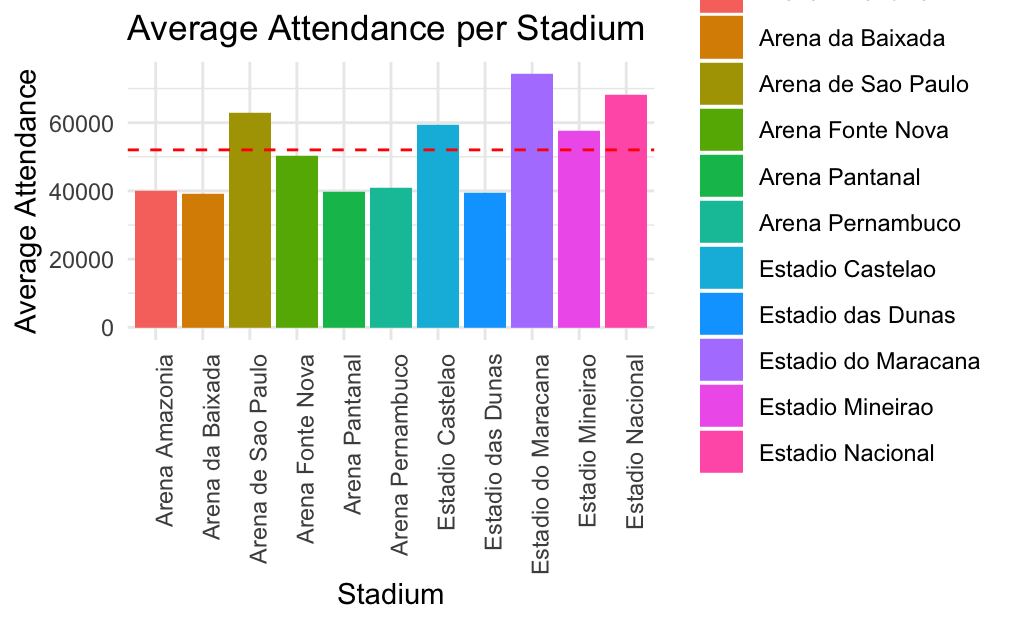

```r
ggplot(stadium_attendance, aes(x = Stadium, y = avg_attendance, fill = Stadium)) +
  geom_bar(stat = "identity") +
  labs(x = "Stadium", y = "Average Attendance") +
  geom_hline(yintercept = mean(stadium_attendance$avg_attendance), color = "red", linetype = "dashed") +
  ggtitle("Average Attendance per Stadium") +
  theme_minimal() +
  theme(axis.text.x = element_text(angle = 90, hjust = 1))
```

> > Above, you can see a barchart with all the stadiums and average attendance per game. The Estadio do Maracana has the highest number of attendance per game. It is also the biggest stadium in Brazil and the one in which Germany beat Brazil 7-1.

# Third data visualization: Number of Games played in each stadium

> > In this section, I want to explore how many games were played in each stadium. Below it can be seen that two stadiums had 10 Games played. The least amount of games are 4. The Estadio de Maracana and the Estadio de Nacional are the ones were most of the Games have been played.

```r
WC_stadium_count <- WC_data %>%
  filter(Year == "2014") %>%
  count(Stadium)
```

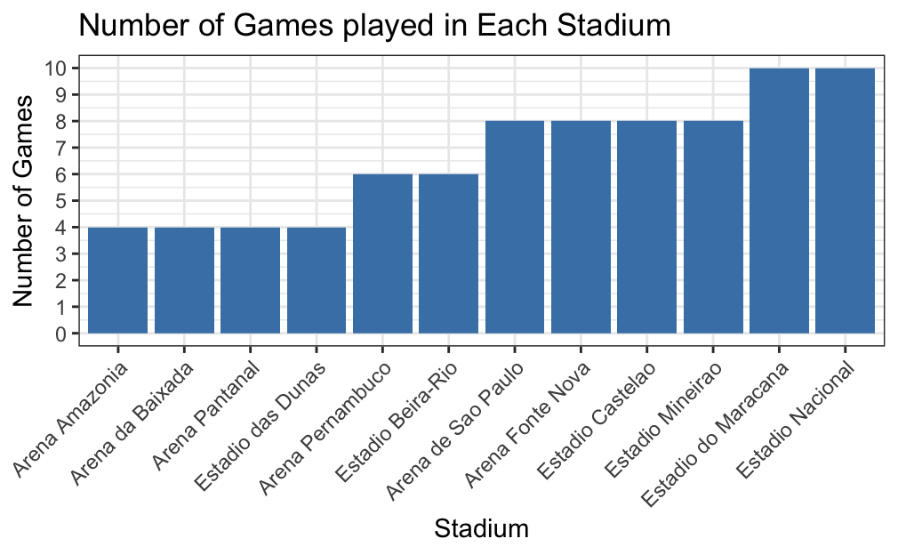

```r
ggplot(WC_stadium_count, aes(x = reorder(Stadium, n), y = n)) +
  geom_bar(stat = "identity", fill = "steelblue") +
  xlab("Stadium") +
  ylab("Number of Games") +
  ggtitle("Number of Games played in Each Stadium") +
  theme_bw() +
  theme(axis.text.x = element_text(angle = 45, hjust = 1)) +
   scale_y_continuous(breaks = seq(0, max(WC_stadium_count$n), by = 1), # to get a continuous y axis with values 0 to 10, only using whole numbers
                     limits = c(0, ceiling(max(WC_stadium_count$n))))
```

# Add on: Exploring next weeks chapter

```r
# Loading all necessary packages
library(ggplot2)
library(maps)
library(mapdata)
library(ggmap)
```

```r
# Filtering and selecting only necessary observations
WC_location <- WC_data %>%
  filter(Year == "2014") %>%
  select(Stadium, City)
```

```r
WC_location$City <- as.character(WC_location$City)
```

> > Sourcing the API from my Desktop instead of typing it in!

```r
api_key <- readLines("/Users/tommann/Desktop/api.txt")
```

```r
ggmap::register_google(key = api_key, write = TRUE)
```

```
ℹ Replacing old key (AIzaSyCL) with new key in /Users/tommann/.Renviron
```

```r
geocode_result <- geocode(as.character(WC_location$City), output = "latlon", source = "google", key = api_key)
```

[output not shown]

```r
WC_location$latitude <- geocode_result$lat
WC_location$longitude <- geocode_result$lon
```

```r
# Retrieve map data for Brazil
brazil_map <- map_data("world", region = "Brazil")
```

```r
WC_location
```

| Stadium | City | latitude | longitude |
| --- | --- | --- | --- |
| Arena de Sao Paulo | Sao Paulo | -23.555771 | -46.63956 |
| Estadio das Dunas | Natal | -28.530554 | 30.89582 |
| Arena Fonte Nova | Salvador | 13.794185 | -88.89653 |
| Arena Pantanal | Cuiaba | -15.595414 | -56.09258 |
| Estadio Mineirao | Belo Horizonte | -19.919052 | -43.93867 |
| Estadio Castelao | Fortaleza | -3.732720 | -38.52701 |
| Arena Amazonia | Manaus | -3.119028 | -60.02173 |
| Arena Pernambuco | Recife | -8.057740 | -34.88296 |
| Estadio Nacional | Brasilia | -15.797515 | -47.89189 |
| Estadio Beira-Rio | Porto Alegre | -30.036818 | -51.20899 |

[output cut: 70 more lines]

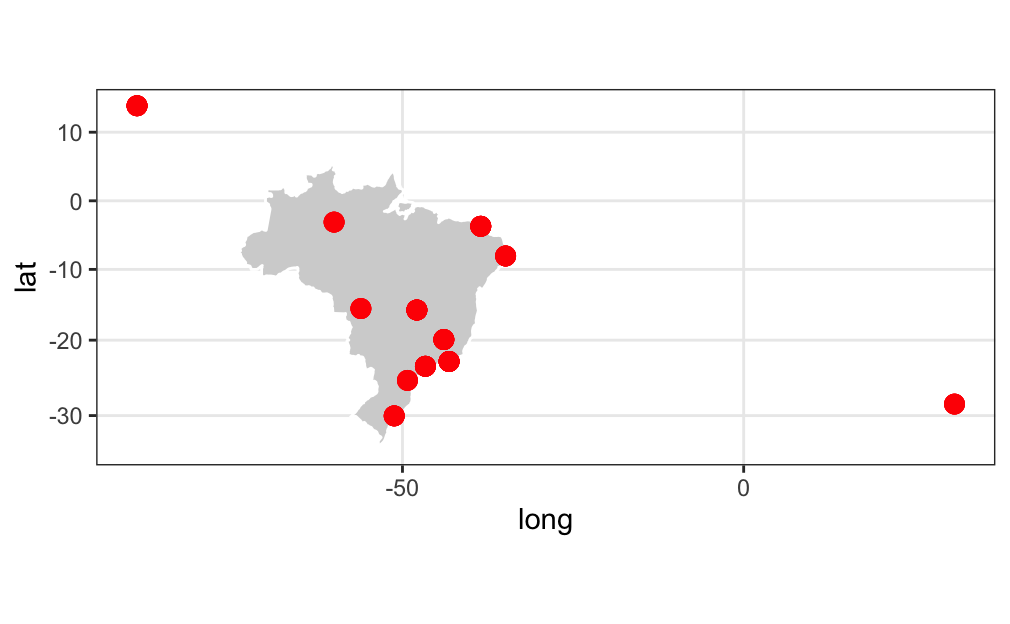

```r
map_plot <- ggplot() +
  geom_polygon(data = brazil_map, aes(x = long, y = lat, group = group), fill = "lightgray", color = "white") +
  geom_point(data = WC_location, aes(x = longitude, y = latitude), color = "red", size = 3) +
  coord_map() +
  theme_bw()

map_plot
```

```r
WC_location %>%
  filter(latitude > 10)
```

| Stadium | City | latitude | longitude |
| --- | --- | --- | --- |
| Arena Fonte Nova | Salvador | 13.79419 | -88.89653 |
| Arena Fonte Nova | Salvador | 13.79419 | -88.89653 |
| Arena Fonte Nova | Salvador | 13.79419 | -88.89653 |
| Arena Fonte Nova | Salvador | 13.79419 | -88.89653 |
| Arena Fonte Nova | Salvador | 13.79419 | -88.89653 |
| Arena Fonte Nova | Salvador | 13.79419 | -88.89653 |
| Arena Fonte Nova | Salvador | 13.79419 | -88.89653 |
| Arena Fonte Nova | Salvador | 13.79419 | -88.89653 |

```r
WC_location %>%
  filter(longitude > 10)
```

| Stadium | City | latitude | longitude |
| --- | --- | --- | --- |
| Estadio das Dunas | Natal | -28.53055 | 30.89582 |
| Estadio das Dunas | Natal | -28.53055 | 30.89582 |
| Estadio das Dunas | Natal | -28.53055 | 30.89582 |
| Estadio das Dunas | Natal | -28.53055 | 30.89582 |

```r
geocode_result_BR <- geocode(as.character("WC_location$City, Brazil"), output = "latlon", source = "google", key = api_key)
```

```r
WC_location$latitude <- geocode_result$lat
WC_location$longitude <- geocode_result$lon
```

```r
# Retrieve map data for Brazil
brazil_map <- map_data("world", region = "Brazil")
```

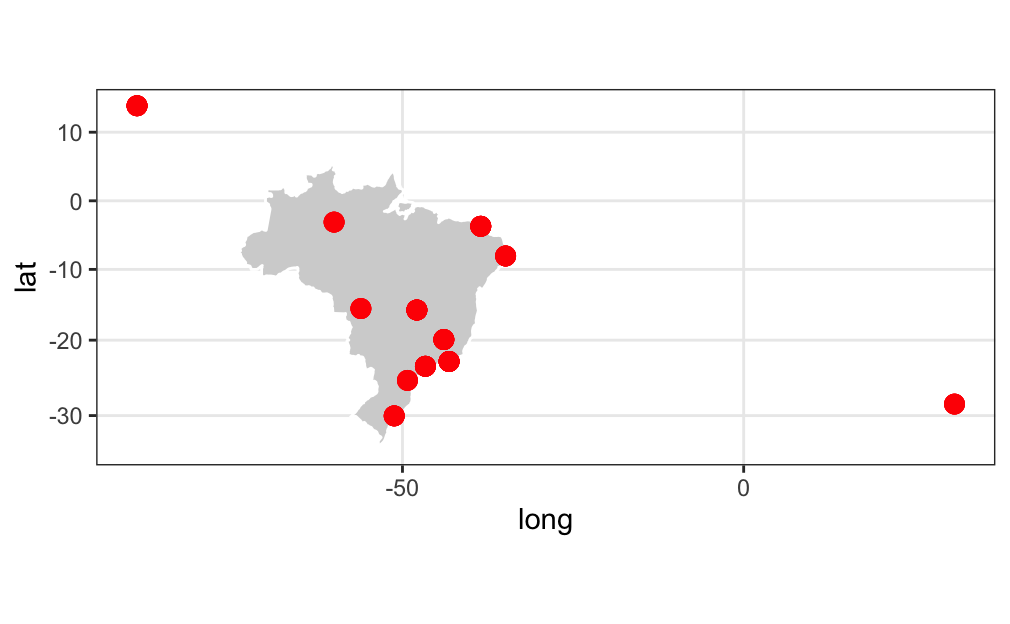

```r
map_plot <- ggplot() +
  geom_polygon(data = brazil_map, aes(x = long, y = lat, group = group), fill = "lightgray", color = "white") +
  geom_point(data = WC_location, aes(x = longitude, y = latitude), color = "red", size = 3) +
  coord_map() +
  theme_bw()

map_plot
```

> > I am gonna adjust the longitude and latitude of both outliers manually to get a better result.

```r
WC_location[WC_location$City == "Salvador", "latitude"] <- -12.974722
WC_location[WC_location$City == "Salvador", "longitude"] <- -38.476665
WC_location[WC_location$City == "Natal", "latitude"] <- -5.812757
WC_location[WC_location$City == "Natal", "longitude"] <- -35.2000
```

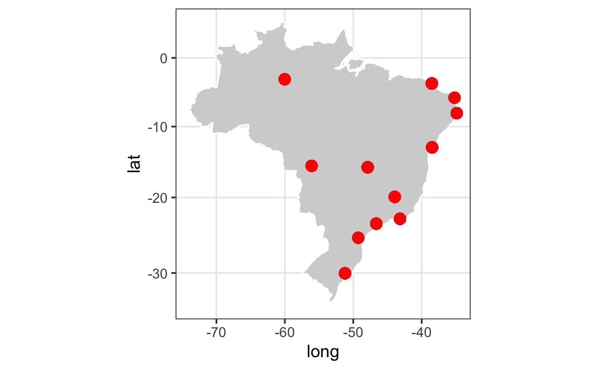

```r
map_plot <- ggplot() +
  geom_polygon(data = brazil_map, aes(x = long, y = lat, group = group), fill = "lightgray", color = "white") +
  geom_point(data = WC_location, aes(x = longitude, y = latitude), color = "red", size = 3) +
  coord_map() +
  theme_bw()

map_plot
```

> > Tadaaa… now we can see that all points are within Brazil. It is interesting to see that most Stadiums lay on the east coast of Brazil.